# Reproducible Research:

## Peer Assessment #1

### Loading and preprocessing the data

*Conditionally (if not already present) download, unzip, and read-in data.*

```r
library(dplyr, warn.conflicts=FALSE)
library(knitr)
dataURL <-                                  ## Download URL
  paste0("https://d396qusza40orc.cloudfront.",
         "net/repdata%2Fdata%2Factivity.zip")
targFileName <- paste0("data/repdata\ ",    ## Local data file name
                       "data\ activity.zip")
dataFileName <- "data/activity.csv"         ## Unzipped data file name

if(!file.exists(dataFileName)) {            ## If not present, download file
  download.file(dataURL,                    ## from web and decompress
               destfile = targFileName,
               method = "curl")
  unzip(targFileName)
}

if(!"actDat" %in% ls()){                    ## If not already loaded,
  actDat <- read.csv(dataFileName)          ## read-in csv data file.
  actDat$date <- as.Date(actDat$date,       ## Change date to Posix format
                       format="%Y-%m-%d")
}
rm(dataURL, targFileName, dataFileName)     ## Cleanup temp data objects
```

### What is mean total number of steps taken per day?

```
Make a histogram of the total number of steps taken each day:
```

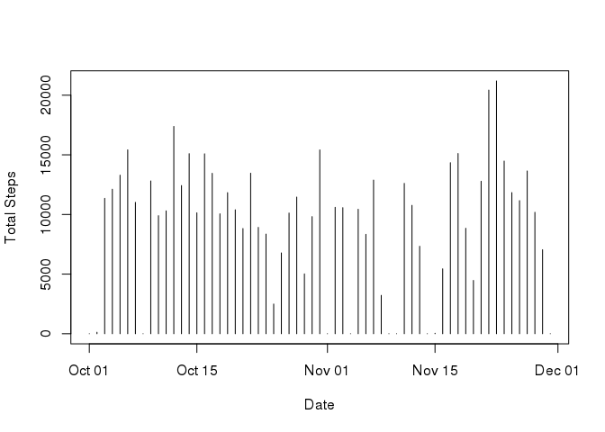

```r
plot(                                       ## H-plot the total steps/day
  na.omit(                                  ## Omits NaN and NA values
    summarize(
      group_by(
        actDat, date),
          sum(steps, na.rm=TRUE))),
  type="h",
  ylab="Total Steps",
  xlab="Date")
```

```r
#dev.copy(png, file = "meanStepsPlot.png")   ## Save plot to separate file
#dev.off()
```

```
Calculate and report the mean and median total number of steps taken per day:
```

```r
print(paste("Average steps per day is",
    formatC(mean(na.omit(
      summarize(group_by(actDat,date),      ## Computes the mean of the sums
                sum(steps,                  ## for each day.  Omits NaN and
                    na.rm=TRUE)))$sum),     ## NA values. Formats to 6 digits.
      digits=6)))
```

```
## [1] "Average steps per day is 9354.23"
```

```r
print(paste("Median steps per day is",
            median(na.omit(                 ## Computes the mid-point of the
                     summarize(             ## sums for each day.  Omits NaN
                       group_by(actDat,     ## and NA values.
                                date),
                       sum(steps,
                           na.rm=TRUE)))$sum)))
```

```
## [1] "Median steps per day is 10395"
```

### What is the average daily activity pattern?

```
Make a time series plot (i.e. type = "l") of the 5-minute interval (x-axis)
and the average number of steps taken, averaged across all days (y-axis)
```

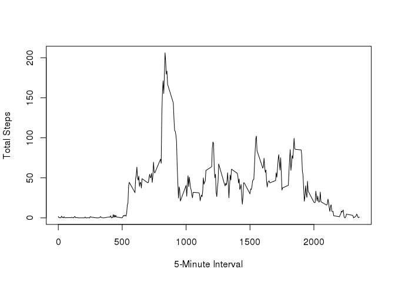

```r
plot(na.omit(summarize(group_by(            ## L-plot the average steps/interval
                                actDat,     ## Omits NaN and NA values
                                interval),
                       mean(steps, na.rm=TRUE))),
                       type="l",
                       ylab="Total Steps",
                       xlab="5-Minute Interval")
```

```r
#dev.copy(png, file =                        ## Save plot to separate file
#           "plotStepsInterval.png")
#dev.off()
```

```
Which 5-minute interval, on average across all the days in the dataset,
contains the maximum number of steps?
```

```r
totals <-                                   ## Vector of interval sums
  summarize(
            group_by(actDat, interval),
            sum(steps, na.rm=TRUE))
maxStep <-                                  ## Largest of vector.
  totals[totals$sum == max(totals$sum), c(1,2)]
hour <-                                     ## Hour component of timestamp for
  as.integer(maxStep$interval/60)           ## largest entry.
minute <-                                   ## Minute component of timestamp for
  ((maxStep$interval/60 - hour)/100) *60    ## vector entry.
second <- (minute - as.integer(minute))*60  ## Estimate peak seconds timestamp
print(paste0("Maximum activity is ",
            maxStep$sum,
            " steps at interval ",
            maxStep$interval,
            " or, occurs approximately at ",
            hour, ":",
            formatC(as.integer(minute),          ## Format minutes.
                    flag=0, width=2),
            ":", second,
            " hours (24-hour clock)"))
```

```
## [1] "Maximum activity is 10927 steps at interval 835 or, occurs approximately at 13:00:33 hours (24-hour clock)"
```

```r
rm(totals, maxStep, hour, minute, second)        ## Explicit cleanup unused vars.
```

### Impute missing values

```
Calculate and report the total number of missing values in the dataset (i.e.
the total number of rows with NAs).
```

```r
sum(as.numeric(is.na(actDat[,1])))
```

```
## [1] 2304
```

```
Devise a strategy for filling in all of the missing values in the datase.
Create a new dataset that is equal to the original dataset but with the
missing data filled in.
```

*Rationale: It is easily determined that NA values are clustered for entire days: in other words, many days have no observations for steps, and do not contribute information to the data.*

```r
for(date in unique(actDat$date)){           ## Code chunk demonstrates that
  print(                                    ## values for step observations are
    paste0(                                 ## sometimes NA for full days by not
         mean(actDat[actDat$date==date, 1]),## using mean(na.omit). Computes the
         " ",                               ## step mean for each day of
         date))                             ## collections. Displays mean with
  }                                         ## the POSIX unformatted date.
```

```
## [1] "NA 15614"
## [1] "0.4375 15615"
## [1] "39.4166666666667 15616"
## [1] "42.0694444444444 15617"
## [1] "46.1597222222222 15618"
## [1] "53.5416666666667 15619"
## [1] "38.2465277777778 15620"
## [1] "NA 15621"
## [1] "44.4826388888889 15622"
## [1] "34.375 15623"
## [1] "35.7777777777778 15624"
## [1] "60.3541666666667 15625"
## [1] "43.1458333333333 15626"
## [1] "52.4236111111111 15627"
## [1] "35.2048611111111 15628"
```

[output cut: 46 more lines]

*Discussion: A valid solution would be to discard records with no valid entries for the day. However, discarding the bad reading dates would not accomplish the instructions from the assignment:*

###### “Create a new dataset that is equal to the original dataset but with the missing data filled in.”

*Strategy: The best compromise solution seems to be to replace observation step NA values with 0 so as not to change the information profile:*

```r
naReplace <-function(steps){                ## Substitutes 0 for NA values.
  if(is.na(steps)){                         ## Returns a vector of steps.
    return(0)
    }
  else{
    return(steps)
    }
  }
newActDat <-                                ## Create a new data frame with the
  data.frame(steps = as.numeric(            ## same sample labels.  Replace all
                      lapply(               ## NA values with the mean of all
                        actDat$steps,       ## days of data collections.
                        naReplace)),
             date=actDat$date, interval=actDat$interval)
dim(newActDat)                              ## Show the size of the new data
```

```
## [1] 17568     3
```

```r
head(newActDat)                             ## Show a sample of the new data
```

```
##   steps       date interval
## 1     0 2012-10-01        0
## 2     0 2012-10-01        5
## 3     0 2012-10-01       10
## 4     0 2012-10-01       15
## 5     0 2012-10-01       20
## 6     0 2012-10-01       25
```

```
Make a histogram of the total number of steps taken each day and Calculate
and report the mean and median total number of steps taken per day. Do these
values differ from the estimates from the first part of the assignment? What
is the impact of imputing missing data on the estimates of the total daily
number of steps?
```

*Histogram below:*

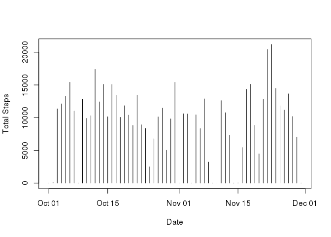

```r
plot(summarize(group_by(newActDat,          ## H-plot the total steps/day.
                        date),              ## Omits NaN and NA values, same as
               sum(steps)),                 ## above.
  type="h",
  ylab="Total Steps",
  xlab="Date")
```

```r
#dev.copy(png, file = "corrDatHist.png")     ## Save plot to separate file
#dev.off()
```

*Mean and Median daily values*

```r
print(paste("Average steps per day is",
    formatC(mean(na.omit(
      summarize(group_by(actDat,date),      ## Computes the mean of the sums
                sum(steps,                  ## for each day.  Omits NaN and
                    na.rm=TRUE)))$sum),     ## NA values. Formats to 6 digits.
      digits=6)))
```

```
## [1] "Average steps per day is 9354.23"
```

```r
print(paste("Median steps per day is",
            median(summarize(group_by(      ## Computes and displays the mid-
                               newActDat,   ## point of the sums for each day.
                               date),       ## Omits NaN and NA values.
            sum(steps))$sum)))
```

```
## [1] "Median steps per day is 10395"
```

*Since the NA data were replaced with zero, the daily sums for the affected days have not changed. The most recent histogram shows the same values as that of the original data, which has the same effect as ommitting NA values in the formulae generating the original plot.*

### Are there differences in activity patterns between weekdays and weekends?

```
Create a new factor variable in the dataset with two levels – “weekday” and
“weekend” indicating whether a given date is a weekday or weekend day.
```

```r
newActDat <-
  mutate(newActDat,                         ## Adds new variable for weekday
         weekday = !grepl("S[a-z]*day",     ## as a boolean. Uses regexp to
                          as.character(     ## detect day names beginning with
                            lapply(         ## "S" and ending in "day."
                              newActDat$date,
                              weekdays))))
dim(newActDat)                              ## Show the size of the new data.
```

```
## [1] 17568     4
```

```r
head(newActDat)                             ## Display a sample of the new data.
```

```
##   steps       date interval weekday
## 1     0 2012-10-01        0    TRUE
## 2     0 2012-10-01        5    TRUE
## 3     0 2012-10-01       10    TRUE
## 4     0 2012-10-01       15    TRUE
## 5     0 2012-10-01       20    TRUE
## 6     0 2012-10-01       25    TRUE
```

```
Make a panel plot containing a time series plot (i.e. type = "l") of the 5-
minute interval (x-axis) and the average number of steps taken, averaged
across all weekday days or weekend days (y-axis).
```

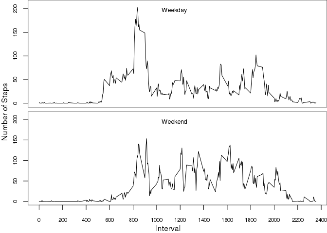

```r
par(mfrow = c(2,1),                         ## Sets up multipanel plots and
    pin = c(10, 10),                        ## other aesthetics.
    mar = c(.5,2,0,0),
    oma = c(1,1,0,0),
    lab = c(10, 6, 5))
plot(summarize(group_by(newActDat[          ## L-plot the average steps/interval
                          newActDat$weekday==TRUE,],
                        interval),          ## for weekdays. Omits NaN and NA
               mean(steps)),                ## values.
  type = "l",
  xaxt = "n",                               ## Omits x axis for the top graph
  ylim = c(0,210),
  xlim = c(0,2355),                         ## but sets x axis interval to match
  cex.axis = .7)
text(1150, 210, "Weekday",pos = 1, cex = .8)## Labels plot data
par(mar = c(2,2,0,0))                       ## Modifies the margin for plot 2
plot(summarize(                             ## L-plot the average steps/interval
       group_by(
         newActDat[newActDat$weekday==FALSE,],
         interval),                         ## for weekend data. Omits NaN and
               mean(steps)),                ## NA values.
  type="l",
  ylim = c(0,210),
  xlim = c(0,2355),
  cex.axis = .7 )
text(1150, 210, "Weekend", pos = 1,         ## Labels the plot
     cex = .8)
mtext("Number of Steps",                    ## Labels the shared axes
      side = 2, outer = TRUE)
mtext("Interval",
      side = 1, outer = TRUE)
```

```r
#dev.copy(png, file = "panelPlot.png")       ## Save plot to separate file
#dev.off()
rm(newActDat)                               ## Explicit cleanup temp data frame
```